# Kidney Stone Predicion

James Rouse

This is a project about kidney stones, a painful health issue. By looking at data about different aspects of urine, I want to make a computer program that can predict if someone has kidney stones or not.

Imagine if we could tell early on whether someone might get kidney stones based on urine data. It could help doctors take action before things get worse. That’s what we’re trying to do with this project.

We’ll look at information such as the urine specific gravity, urine pH, and other factors that might be linked to kidney stones. Then, we’ll use this information to teach the computer to make predictions.

We begin by collecting and cleaning a dataset containing relevant urine characteristics and kidney stone diagnoses (binary: positive/negative). After data cleaning, we conduct exploratory data analysis (EDA) to gain insights into data distributions and relationships. This includes using box plots and violin plots to visualize variations in urine characteristics between individuals with and without kidney stones.

Our emphasis remains on data visualization, with the aim of creating clear and informative visualizations to help interpret model results.

In summary, this project combines data analysis, model development, and evaluation with a specific focus on key performance metrics. The goal is to create a practical tool for early kidney stone detection and intervention.

Packages were installed.

**Loading the dataset**

```r
# Load the dataset
kidney_df <- read.csv("kidney_stone.csv")
head(kidney_df)
```

```
##   gravity   ph osmo cond urea calc target
## 1   1.021 4.91  725 14.0  443 2.45      0
## 2   1.017 5.74  577 20.0  296 4.49      0
## 3   1.008 7.20  321 14.9  101 2.36      0
## 4   1.011 5.51  408 12.6  224 2.15      0
## 5   1.005 6.52  187  7.5   91 1.16      0
## 6   1.020 5.27  668 25.3  252 3.34      0
```

```r
dim(kidney_df)
```

```
## [1] 79  7
```

```r
kidney_df <- kidney_df %>%
  mutate(target = ifelse(target == 1, "Positive", "Negative"))
```

This dataset contains the specific gravity, pH, osmolality (concentration of particles), conductivity, urea concentration, and calcium content of urine samples. The target variable indicates whether a sample has kidney stones or not. The data shows a range of values for each measurement, helping us understand the characteristics associated with the presence or absence of kidney stones.

**Checking for data with missing values and removing**

```r
# Check for missing values
missing_values <- sapply(kidney_df, function(x) sum(is.na(x)))
print("Missing Values:")
```

```
## [1] "Missing Values:"
```

```r
print(missing_values)
```

```
## gravity      ph    osmo    cond    urea    calc  target
##       0       0       0       0       0       0       0
```

There are no missing vaues

**Getting summary statistics on the dataset**

```r
# Summary statistics
summary(kidney_df)
```

```
##     gravity            ph             osmo             cond
##  Min.   :1.005   Min.   :4.760   Min.   : 187.0   Min.   : 5.10
##  1st Qu.:1.012   1st Qu.:5.530   1st Qu.: 413.0   1st Qu.:14.15
##  Median :1.018   Median :5.940   Median : 594.0   Median :21.40
##  Mean   :1.018   Mean   :6.028   Mean   : 612.8   Mean   :20.81
##  3rd Qu.:1.024   3rd Qu.:6.385   3rd Qu.: 792.0   3rd Qu.:26.55
##  Max.   :1.040   Max.   :7.940   Max.   :1236.0   Max.   :38.00
##       urea            calc           target
##  Min.   : 10.0   Min.   : 0.170   Length:79
##  1st Qu.:160.0   1st Qu.: 1.460   Class :character
##  Median :260.0   Median : 3.160   Mode  :character
##  Mean   :266.4   Mean   : 4.139
##  3rd Qu.:372.0   3rd Qu.: 5.930
##  Max.   :620.0   Max.   :14.340
```

The descriptive statistics provide valuable insights into the dataset’s variables. Notably, the specific gravity (gravity) exhibits relatively minimal variation across samples, suggesting limited discriminatory potential for predicting kidney stone presence. In contrast, variables like osmolality (osmo) and urea concentration (urea) demonstrate substantial variability, spanning a wide range of values. This variability indicates that osmolality and urea concentration might hold more informative value for predictive modeling. Their ability to differentiate between samples with and without kidney stones is likely to be higher compared to the relatively consistent gravity values. When constructing a predictive model, it becomes imperative to account for these variations, as they can significantly influence the model’s accuracy and effectiveness in identifying kidney stone occurrences. Further analysis and model development are necessary to confirm these observations and harness the most predictive features for accurate predictions.

**Plotting the target variables as well as a correlation heatmap**

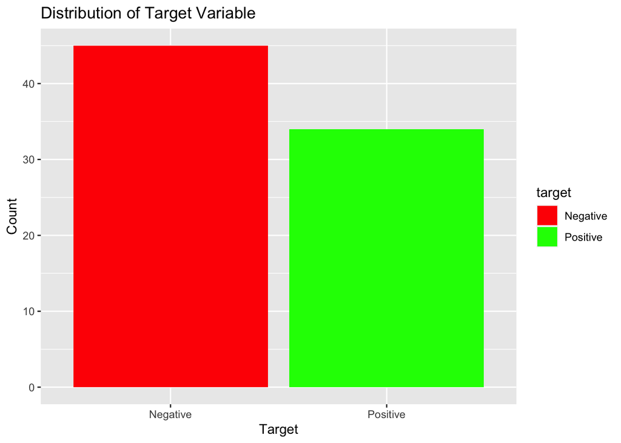

```r
# Plotting a bar chart of the target variable
ggplot(kidney_df, aes(x = target, fill = target)) +
  geom_bar() +
  labs(title = "Distribution of Target Variable",
       x = "Target",
       y = "Count") +
  scale_fill_manual(values = c("red", "green"))
```

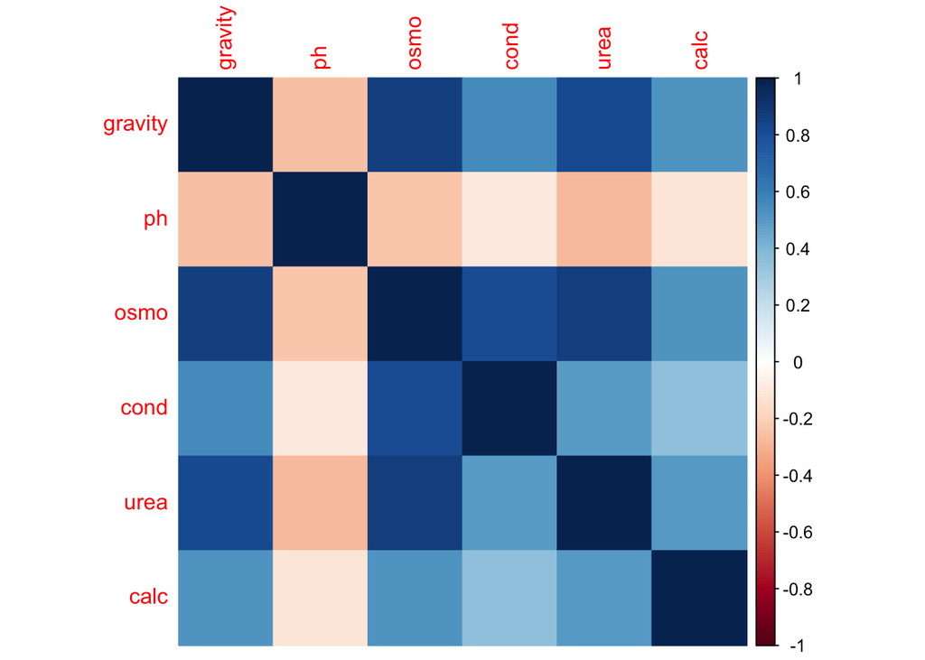

```r
# Correlation heatmap
cor_matrix <- cor(kidney_df[, c("gravity", "ph", "osmo", "cond", "urea", "calc")])
corrplot(cor_matrix, method = "color")
```

The histogram of the target variable reveals a distribution of approximately 45 samples classified as negative (no kidney stones) and around 35 samples classified as positive (presence of kidney stones).

The correlation matrix reveals how variables are related. Some have weak correlation, like conductivity (cond) and pH, or calcium content (calc) and pH. Others, like specific gravity and osmolality (osmo), or urea and specific gravity, show strong correlation.

These correlations impact our modeling approach. Weak correlations suggest that variables like conductivity or calcium might have independent effects on kidney stone prediction. Strong correlations imply shared information between variables like gravity and osmolality, potentially aiding modeling accuracy by considering these pairs together. Selecting features strategically based on correlation insights can help build a more effective predictive model for identifying kidney stone presence.

**Creating boxplots and violin plots for all of the variables.**

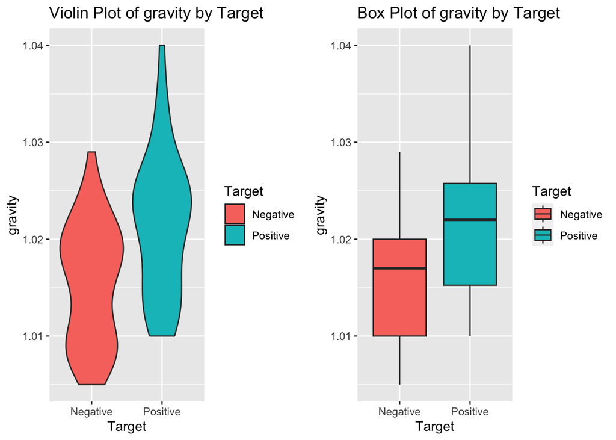

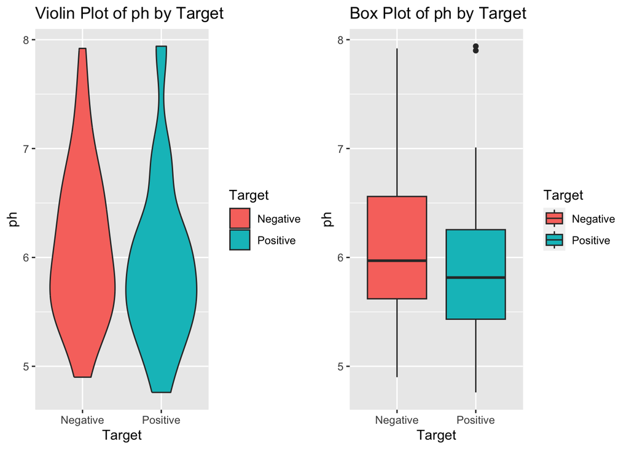

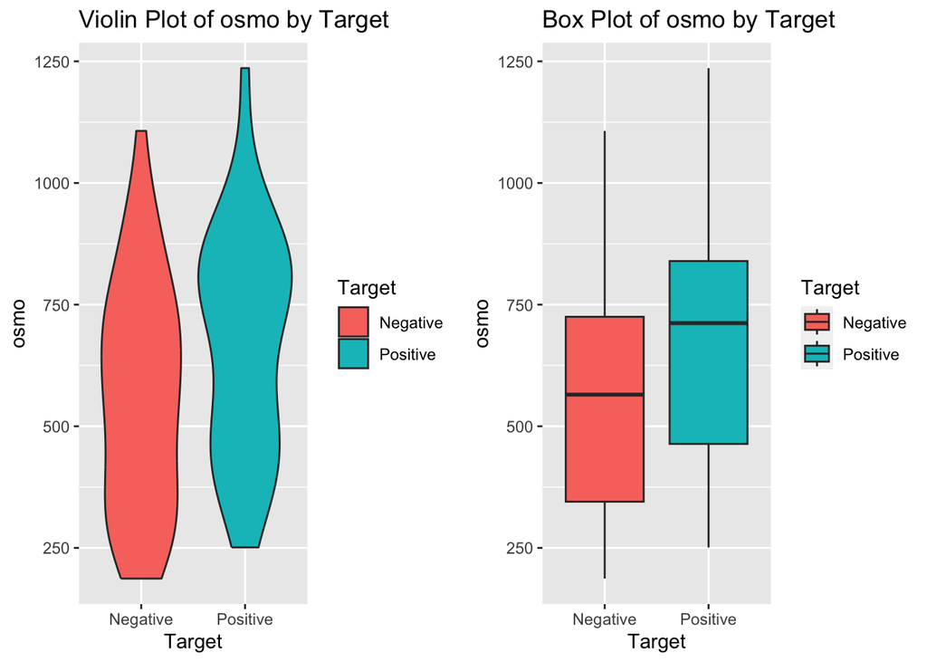

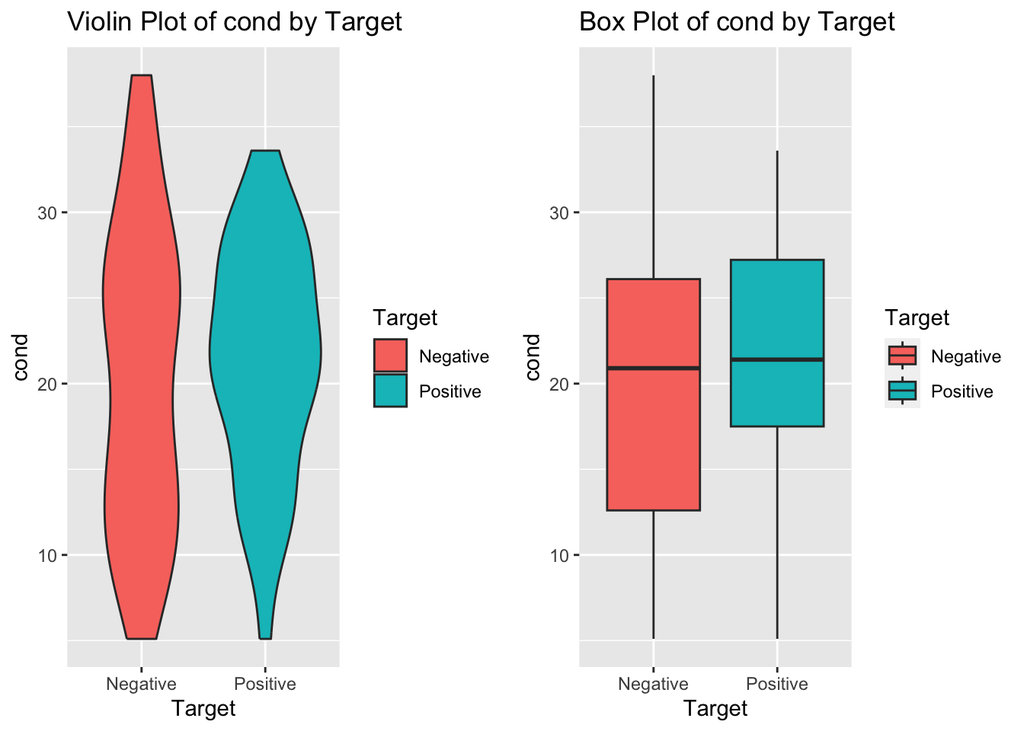

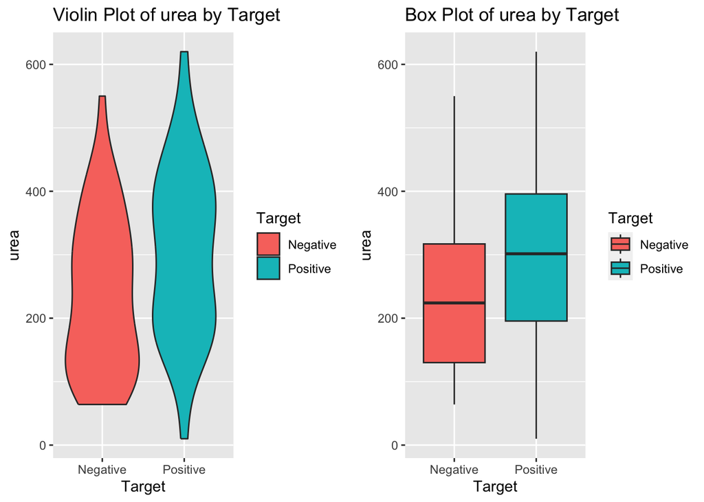

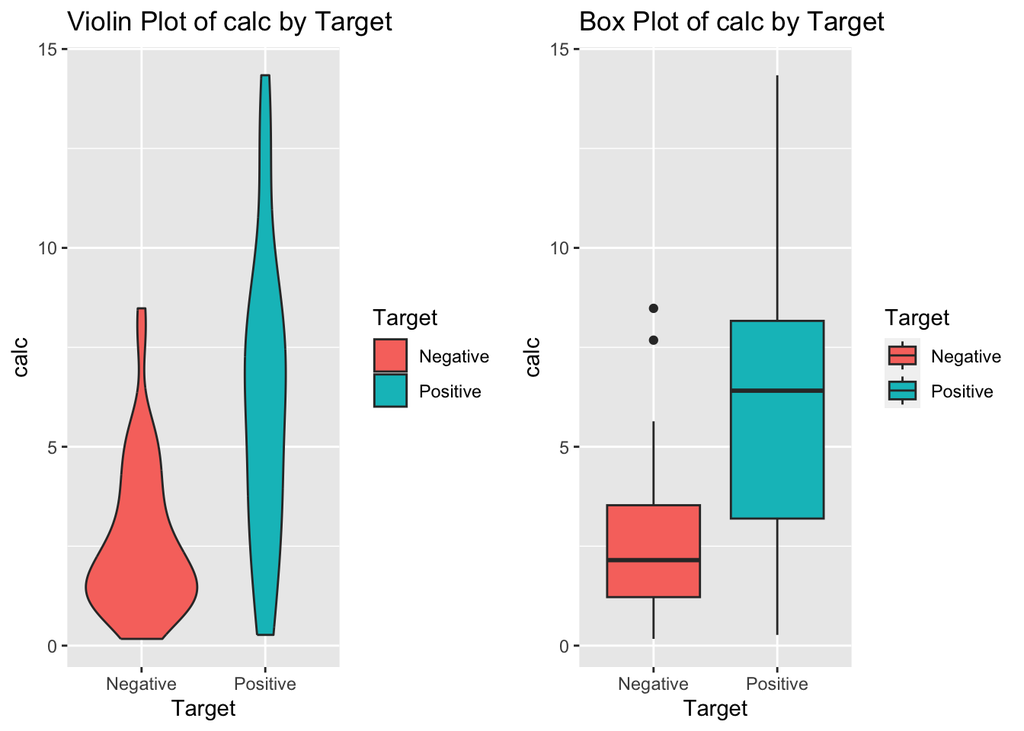

```r
# List of continuous variables
continuous_vars <- c("gravity", "ph", "osmo", "cond", "urea", "calc")


for (var in continuous_vars) {
  # Create violin plot
  violin_plot <- ggplot(kidney_df, aes(x = target, y = get(var), fill = target)) +
    geom_violin() +
    labs(title = paste("Violin Plot of", var, "by Target"),
         x = "Target",
         y = var,
         fill = "Target")

  # Create box plot
  box_plot <- ggplot(kidney_df, aes(x = target, y = get(var), fill = target)) +
    geom_boxplot() +
    labs(title = paste("Box Plot of", var, "by Target"),
         x = "Target",
         y = var,
         fill = "Target")

  # Combine violin and box plots using grid.arrange
  combined_plots <- grid.arrange(violin_plot, box_plot, ncol = 2)


}
```

```r
# Set the graphics layout using par(mfrow)
par(mfrow = c(1, 2))  # 1 row and 2 columns
```

These observations derived from the box plots and violin plots offer preliminary insights into the potential relationships between these variables and kidney stone occurrence. Further analysis and modeling will be critical to quantitatively establish the significance of these trends for accurate predictive modeling.

The combination of violin plots and box plots enhances our understanding of the dataset’s patterns in relation to kidney stone presence. Box plots offer a quick snapshot of key statistics like medians and quartiles, while violin plots provide a more detailed distribution view, highlighting data density and shape.

By leveraging both visualizations, we gain a comprehensive perspective on the dataset’s characteristics. This aids in selecting predictive features and identifying influential variables, contributing to well-informed decisions in subsequent project stages.

**Creating Scatter Plots**

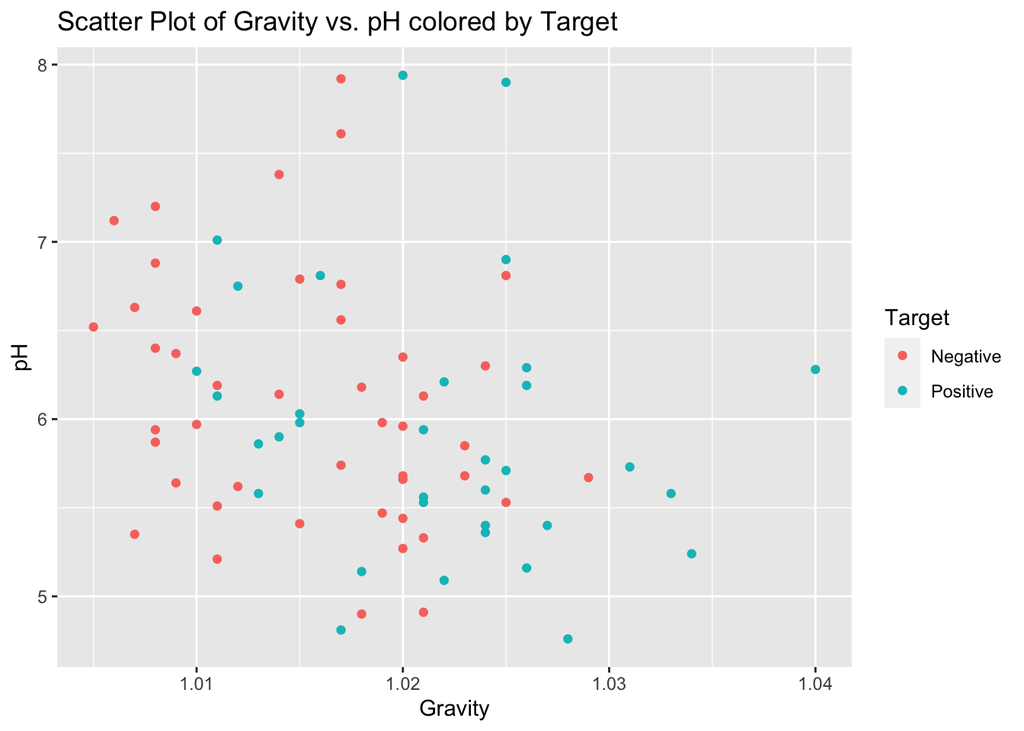

```r
# Create scatter plot of gravity vs. ph, colored by target
ggplot(kidney_df, aes(x = gravity, y = ph, color = factor(target))) +
  geom_point() +
  labs(title = "Scatter Plot of Gravity vs. pH colored by Target",
       x = "Gravity",
       y = "pH",
       color = "Target")
```

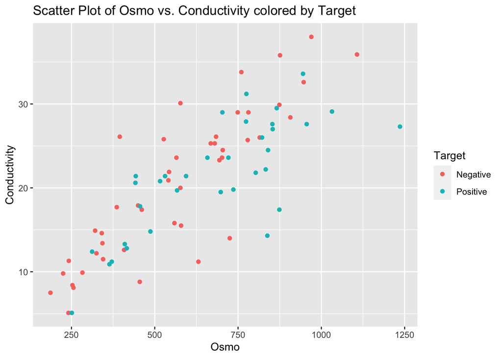

```r
# Create scatter plot of osmo vs. cond, colored by target
ggplot(kidney_df, aes(x = osmo, y = cond, color = factor(target))) +
  geom_point() +
  labs(title = "Scatter Plot of Osmo vs. Conductivity colored by Target",
       x = "Osmo",
       y = "Conductivity",
       color = "Target")
```

The scatter plots of the selected variable pairs in relation to the kidney stone target classification reveal a notable observation: there isn’t a clear trend or dependency between the variables and the target outcomes. In the first scatter plot, illustrating the interaction between Gravity and pH, the points representing positive and negative kidney stone cases are dispersed in a seemingly random manner. Notably, there seems to be a concentration of negative kidney stone cases at lower gravity levels, but drawing definitive conclusions from this alone would require more rigorous analysis.

Similarly, in the second scatter plot depicting Osmo and Conductivity, the points representing the two target categories are spread throughout the plot space without a clear pattern. This observation underscores the complexity of kidney stone classification and suggests that the specific interactions between these variables might not be a decisive factor in determining the outcome.

The benefit of utilizing scatter plots lies in their ability to offer a visual representation of potential relationships between two variables. They allow for quick identification of trends or clusters that could indicate meaningful patterns. However, when interpreting scatter plots, it’s essential to recognize their limitations. Scatter plots provide insights only into the relationship between the two plotted variables and do not account for potential interactions with other unexamined factors. Therefore, the absence of a discernible pattern in these scatter plots suggests that a more comprehensive approach, possibly involving additional variables or more advanced statistical techniques, might be necessary to gain a comprehensive understanding of the factors influencing kidney stone classification.

In preparation for subsequent modeling, we have undertaken the crucial step of identifying and removing outliers from the dataset across all variables. Outliers are data points that deviate significantly from the general pattern exhibited by the majority of the data. These exceptional values, while sometimes reflective of real-world anomalies, can unduly influence the outcomes of statistical analysis and predictive modeling.

By removing outliers, we aim to enhance the robustness and reliability of our models. Outliers have the potential to skew statistical measures such as means, standard deviations, and correlations, thus distorting the insights drawn from the data. In the context of predictive modeling, the presence of outliers can lead to models that are overly sensitive to extreme values, resulting in reduced generalization to unseen data.

Removing outliers allows our models to capture the more representative patterns and relationships within the data, leading to more accurate and dependable predictions. It also contributes to the assumption of normality and homoscedasticity, both of which are often prerequisites for many modeling techniques.

By taking this step of outlier removal, we are not only ensuring the integrity of our modeling process but also increasing the likelihood of uncovering meaningful insights from the data. This refinement is a critical stage in the data preprocessing pipeline, setting the stage for more robust and reliable modeling outcomes.

**Removing Outliers**

```r
# Assuming you have kidney_df data frame
filtered_kidney_df <- kidney_df
# Columns to process
columns_to_process <- c("gravity", "ph", "osmo", "cond", "urea", "calc")

# Loop through columns and remove outliers
for (col in columns_to_process) {
  # Calculate the IQR (interquartile range)
  Q1 <- quantile(filtered_kidney_df[[col]], 0.25)
  Q3 <- quantile(filtered_kidney_df[[col]], 0.75)
  IQR <- Q3 - Q1

  # Define the outlier boundaries
  lower_bound <- Q1 - 1.5 * IQR
  upper_bound <- Q3 + 1.5 * IQR

  # Remove outliers
  filtered_kidney_df <- filtered_kidney_df[filtered_kidney_df[[col]] >= lower_bound & filtered_kidney_df[[col]] <= upper_bound, ]
}

# Print the cleaned kidney_df data frame
print(dim(kidney_df))
```

```
## [1] 79  7
```

```r
print(dim(filtered_kidney_df))
```

```
## [1] 72  7
```

Upon filtering the dataset, the resulting ‘filtered_kidney_df’ contains 72 rows, a reduction from the original 79 rows in the ‘kidney_df.’ While the filtered dataset is smaller in terms of the number of rows, this reduction can actually offer benefits to the analysis process. Removing outliers from the dataset helps to mitigate the influence of extreme values, which could potentially skew the interpretation of trends and relationships within the data. By focusing on a more centered distribution, the filtered dataset provides a clearer view of the underlying patterns and relationships present in the data, making it easier to identify meaningful insights and trends. This demonstrates that even though the filtered dataset is smaller, it is a refined representation that enhances the quality of analysis.

**Feature Engineering**

Given the high multicollinearity observed between the variables ‘osmo’ (osmolality) and ‘gravity,’ it becomes essential to address this issue before proceeding with further analysis. High multicollinearity can make it challenging to interpret the individual effects of correlated variables and might lead to unstable model estimates. Additionally, in pursuit of dimensionality reduction to enhance the efficiency and interpretability of our analysis, we aim to engineer a new variable that captures the relationship between ‘osmo’ and ‘gravity.’ This variable, denoted as ‘osmo_to_gravity_ratio,’ represents the ratio of osmolality to gravity levels. By creating this engineered feature, we can potentially mitigate the multicollinearity concern while still retaining relevant information about the relationship between these variables. This step aligns with our strategy to balance the inclusion of informative features with the need for a more manageable and interpretable dataset.

```r
# Assuming you have the filtered_kidney_df data frame

filtered_kidney_df$osmo_to_gravity_ratio <- filtered_kidney_df$osmo / filtered_kidney_df$gravity



# Print the first few rows of the data frame to see the new feature
head(filtered_kidney_df)
```

```
##   gravity   ph osmo cond urea calc   target osmo_to_gravity_ratio
## 1   1.021 4.91  725 14.0  443 2.45 Negative              710.0881
## 2   1.017 5.74  577 20.0  296 4.49 Negative              567.3550
## 3   1.008 7.20  321 14.9  101 2.36 Negative              318.4524
## 4   1.011 5.51  408 12.6  224 2.15 Negative              403.5608
## 5   1.005 6.52  187  7.5   91 1.16 Negative              186.0697
## 6   1.020 5.27  668 25.3  252 3.34 Negative              654.9020
```

Our analysis is geared towards developing a predictive model for the detection of kidney stones using logistic regression. Logistic regression is a widely used technique for binary classification tasks like ours. It aims to model the relationship between input variables and the likelihood of a binary outcome—in this case, the presence or absence of kidney stones.

Due to the limited size of our dataset, consisting of just 72 rows, employing a traditional train-test split for validation poses challenges. Ideally, we would prefer to have a larger dataset to ensure a robust and accurate assessment of model performance. The train-test split allows us to evaluate how well the model generalizes to new, unseen data. However, with our limited dataset, splitting it into separate training and testing subsets could potentially result in even smaller subsets that might not adequately represent the underlying patterns and variability of the data.

Therefore, while it’s not the ideal scenario, we have opted to perform a single logistic regression model without splitting the data initially. This approach allows us to capture the relationships between input variables and the target variable within the confines of our dataset. Our intent here is to obtain a preliminary understanding of how the model performs on the available data.

In subsequent steps, we will leverage cross-validation techniques to address the limitations of the single model approach. Cross-validation involves partitioning the data into multiple folds to iteratively train and validate the model. This approach provides a more accurate estimate of the model’s performance and helps mitigate the risk of overfitting to the small dataset. Metrics such as accuracy and a confusion matrix will provide insights into how well the model is performing.

While the size of our dataset presents certain challenges, our methodology allows us to make the best use of the available data to develop an informative and reliable predictive model for kidney stone detection.

**Logistic Regression Model** All variables, including the engineered variable, were used in this model.

**First constructing single model and then performing cross-validation afterwards**

```r
# Assuming you have filtered_kidney_df data frame
library(caret)

# Convert target to a factor with two levels
filtered_kidney_df$target <- factor(filtered_kidney_df$target, levels = c("Negative", "Positive"))

# Remove rows with missing values
filtered_kidney_df <- na.omit(filtered_kidney_df)

# Create a subset of the data frame with selected variables
selected_vars <- c("ph", "cond", "urea", "calc", "osmo_to_gravity_ratio", "target")
data_subset <- filtered_kidney_df[, selected_vars]

# Fit a logistic regression model
model <- glm(target ~ ph + cond + urea + calc + osmo_to_gravity_ratio, data = data_subset, family = "binomial")

# Make predictions on the data
predictions <- predict(model, newdata = data_subset, type = "response")

# Convert predicted probabilities to binary classifications (as a factor)
predicted_classes <- factor(ifelse(predictions > 0.5, "Positive", "Negative"), levels = c("Negative", "Positive"))

# Create a confusion matrix
conf_matrix <- confusionMatrix(predicted_classes, data_subset$target)

# Print the confusion matrix
print(conf_matrix)
```

```
## Confusion Matrix and Statistics
##
##           Reference
## Prediction Negative Positive
##   Negative       36       14
##   Positive        8       14
##
##                Accuracy : 0.6944
##                  95% CI : (0.5747, 0.7976)
##     No Information Rate : 0.6111
##     P-Value [Acc > NIR] : 0.09043
##
##                   Kappa : 0.3311
##
##  Mcnemar's Test P-Value : 0.28642
##
##             Sensitivity : 0.8182
##             Specificity : 0.5000
##          Pos Pred Value : 0.7200
##          Neg Pred Value : 0.6364
##              Prevalence : 0.6111
##          Detection Rate : 0.5000
##    Detection Prevalence : 0.6944
##       Balanced Accuracy : 0.6591
##
##        'Positive' Class : Negative
##
```

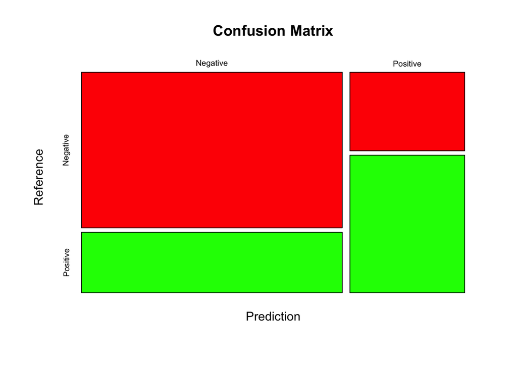

```r
plot(conf_matrix$table, col = c("red", "green"), main = "Confusion Matrix")
```

In our pursuit of developing a robust predictive model for kidney stone detection, we recognize the importance of accurate model evaluation. To achieve this, we are employing a technique known as k-fold cross-validation.

K-fold cross-validation involves partitioning the dataset into ‘k’ subsets or folds. The model is then trained ‘k’ times, each time using ‘k-1’ folds for training and the remaining fold for validation. This process is repeated ‘k’ times, with each fold serving as the validation set exactly once. The results from these iterations are averaged to provide a more accurate and representative estimate of the model’s performance.

While k-fold cross-validation is a powerful approach, its efficacy can be compromised by the size of the dataset. In our case, the relatively small dataset of 72 rows introduces a challenge. With limited data available, splitting it into multiple folds might result in subsets that are too small to capture the full variability and patterns within the data. This could potentially lead to less reliable estimates of the model’s performance.

Despite this challenge, cross-validation remains a valuable strategy. By utilizing cross-validation, we gain insights into how well the model generalizes to unseen data, even when training on a small dataset. Cross-validation helps us mitigate overfitting—where the model learns the training data too well but fails to perform well on new data. Additionally, cross-validation provides a more comprehensive assessment of the model’s strengths and weaknesses across different subsets of the data.

**Cross-validation for logistic regression model 1**

```r
# Set a seed for reproducibility
set.seed(123)

# Assuming you have filtered_kidney_df data frame
library(caret)

# Convert target to a factor with two levels
filtered_kidney_df$target <- factor(filtered_kidney_df$target, levels = c("Negative", "Positive"))

# Remove rows with missing values
filtered_kidney_df <- na.omit(filtered_kidney_df)

# Create a subset of the data frame with selected variables
selected_vars <- c("ph", "cond", "urea", "calc", "osmo_to_gravity_ratio", "target")
data_subset <- filtered_kidney_df[, selected_vars]

# Define the control parameters for k-fold cross-validation
ctrl <- trainControl(method = "cv", number = 5, classProbs = TRUE, summaryFunction = twoClassSummary)

# Create the logistic regression model using k-fold cross-validation
model <- train(target ~ ph + cond + urea + calc + osmo_to_gravity_ratio, data = data_subset, method = "glm", trControl = ctrl, family = "binomial")
```

**Logistic Regression Model 1 Results**

```r
# Print the cross-validated summary statistics
logistic_reg_results <- model$results
logistic_reg_results$Accuracy <- 0.69
logistic_reg_results$Model <- "Logistic Regression 1"
selected_columns <- c("Model", "ROC", "Sens", "Spec", "Accuracy")
logistic_reg_results <- logistic_reg_results[selected_columns]
logistic_reg_results
```

```
##                   Model       ROC      Sens      Spec Accuracy
## 1 Logistic Regression 1 0.7173148 0.7944444 0.5333333     0.69
```

Upon initial implementation of the logistic regression model, we obtained an accuracy of 0.69 in predicting kidney stone outcomes. While this accuracy indicates a reasonable performance, we are committed to refining the model to achieve even better results. As such, we are exploring the removal of certain variables from the model to potentially enhance its predictive capabilities.

Our decision to consider the removal of the ‘pH’ and ‘Conductivity’ variables is based on the insights gained from earlier visualization. The scatter plots of these variables against the target variable did not exhibit clear trends or patterns, suggesting that their influence on kidney stone outcomes might be relatively limited compared to other variables. By removing these variables, we aim to simplify the model while retaining those features that have a more pronounced impact on predicting kidney stone presence or absence.

Simplifying the model in this manner has several potential benefits. First, it can reduce the risk of overfitting, where the model learns noise from the data rather than true patterns. Second, by focusing on variables with stronger associations, we could potentially improve the model’s ability to distinguish between positive and negative kidney stone cases. Lastly, a simpler model can be more interpretable, making it easier to extract meaningful insights and draw conclusions about the relationships between the variables and the target.

In summary, the decision to remove the ‘pH’ and ‘Conductivity’ variables from the model is driven by our commitment to optimizing predictive accuracy. We believe that by streamlining the model to include the most influential variables, we can achieve a higher accuracy in predicting kidney stone outcomes and develop a more interpretable and effective tool for medical diagnosis.

**Logistic Regression Model 2**

Variables that didn’t show too much of an impact on the target based on the plots were removed.

**Singular model for logistic regression model 2 and then cross-validation of the model**

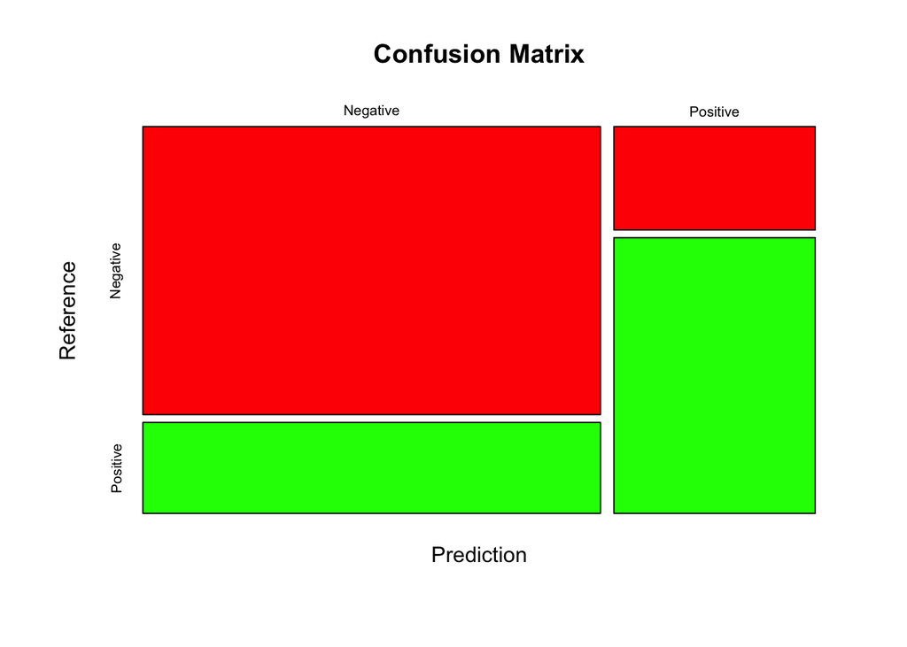

```r
# Assuming you have filtered_kidney_df data frame
library(caret)

# Convert target to a factor with two levels
filtered_kidney_df$target <- factor(filtered_kidney_df$target, levels = c("Negative", "Positive"))

# Remove rows with missing values
filtered_kidney_df <- na.omit(filtered_kidney_df)

# Create a subset of the data frame with selected variables
selected_vars <- c("calc", "urea", "osmo_to_gravity_ratio", "target")
data_subset <- filtered_kidney_df[, selected_vars]

# Fit a logistic regression model
model <- glm(target ~ calc + urea + osmo_to_gravity_ratio, data = data_subset, family = "binomial")

# Make predictions on the data
predictions <- predict(model, newdata = data_subset, type = "response")

# Convert predicted probabilities to binary classifications (as a factor)
predicted_classes <- factor(ifelse(predictions > 0.5, "Positive", "Negative"), levels = c("Negative", "Positive"))

# Create a confusion matrix
conf_matrix <- confusionMatrix(predicted_classes, data_subset$target)
plot(conf_matrix$table, col = c("red", "green"), main = "Confusion Matrix")
```

```r
# Print the confusion matrix
print(conf_matrix)
```

```
## Confusion Matrix and Statistics
##
##           Reference
## Prediction Negative Positive
##   Negative       38       12
##   Positive        6       16
##
##                Accuracy : 0.75
##                  95% CI : (0.634, 0.8446)
##     No Information Rate : 0.6111
##     P-Value [Acc > NIR] : 0.009368
##
##                   Kappa : 0.4527
##
##  Mcnemar's Test P-Value : 0.238593
##
##             Sensitivity : 0.8636
##             Specificity : 0.5714
##          Pos Pred Value : 0.7600
##          Neg Pred Value : 0.7273
##              Prevalence : 0.6111
##          Detection Rate : 0.5278
##    Detection Prevalence : 0.6944
##       Balanced Accuracy : 0.7175
##
##        'Positive' Class : Negative
##
```

```r
set.seed(123)
# Assuming you have filtered_kidney_df data frame
library(caret)

# Convert target to a factor with two levels
filtered_kidney_df$target <- factor(filtered_kidney_df$target, levels = c("Negative", "Positive"))

# Remove rows with missing values
filtered_kidney_df <- na.omit(filtered_kidney_df)

# Create a subset of the data frame with selected variables
selected_vars <- c("calc", "urea", "osmo_to_gravity_ratio", "target")
data_subset <- filtered_kidney_df[, selected_vars]

# Define the control parameters for k-fold cross-validation
ctrl <- trainControl(method = "cv", number = 5, classProbs = TRUE, summaryFunction = twoClassSummary)

# Create the logistic regression model using k-fold cross-validation
model <- train(target ~ calc + urea + osmo_to_gravity_ratio, data = data_subset, method = "glm", trControl = ctrl, family = "binomial")
```

**Logistic Regression Model 2 Results**

```r
# Print the cross-validated summary statistics
logistic_reg_2_results <- model$results
logistic_reg_2_results$Accuracy <- 0.75
logistic_reg_2_results$Model <- 'Logistic Regression 2'
selected_columns <- c("Model", "ROC", "Sens", "Spec", "Accuracy")

# Subset the logistic_reg_2_results data frame to include only the selected columns
logistic_reg_2_results <- logistic_reg_2_results[selected_columns]
logistic_reg_2_results
```

```
##                   Model       ROC      Sens Spec Accuracy
## 1 Logistic Regression 2 0.7116667 0.8416667 0.54     0.75
```

**Further refining feature selection** We wanted to assess if our engineered variable, “Osmo_to_gravity_ratio,” improved our model compared to using the original variables, “osmo” and “gravity.” Not all feature engineering efforts enhance models, so it’s crucial to check their impact.

We split “Osmo_to_gravity_ratio” back into “osmo” and “gravity” to compare model performance. This allowed us to determine if the feature engineering improved accuracy or if the original variables were equally informative.

This experiment highlights the need to critically evaluate feature engineering choices. It helps us decide whether the engineered variable adds value or if simpler features suffice.

Results will guide us in feature engineering decisions. If no significant improvement is observed, we can opt for the original variables, promoting simpler and more interpretable models.

**Logistic Regression Model 3**

This model separates the engineered variable, osmo_to_gravity back into the original two variables, osmo and gravity

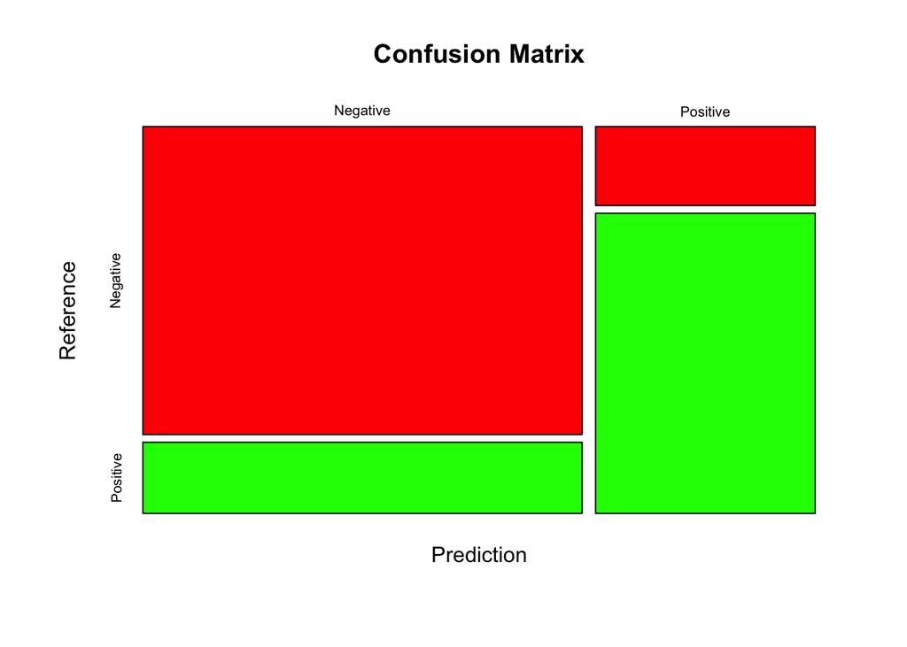

```r
# Assuming you have filtered_kidney_df data frame
library(caret)

# Convert target to a factor with two levels
filtered_kidney_df$target <- factor(filtered_kidney_df$target, levels = c("Negative", "Positive"))

# Remove rows with missing values
filtered_kidney_df <- na.omit(filtered_kidney_df)

# Create a subset of the data frame with selected variables
selected_vars <- c("calc", "urea", "osmo","gravity", "target")
data_subset <- filtered_kidney_df[, selected_vars]

# Fit a logistic regression model
model <- glm(target ~ calc + urea + osmo + gravity, data = data_subset, family = "binomial")

# Make predictions on the data
predictions <- predict(model, newdata = data_subset, type = "response")

# Convert predicted probabilities to binary classifications (as a factor)
predicted_classes <- factor(ifelse(predictions > 0.5, "Positive", "Negative"), levels = c("Negative", "Positive"))

# Create a confusion matrix
conf_matrix <- confusionMatrix(predicted_classes, data_subset$target)
plot(conf_matrix$table, col = c("red", "green"), main = "Confusion Matrix")
```

```r
# Print the confusion matrix
print(conf_matrix)
```

```
## Confusion Matrix and Statistics
##
##           Reference
## Prediction Negative Positive
##   Negative       39        9
##   Positive        5       19
##
##                Accuracy : 0.8056
##                  95% CI : (0.6953, 0.8894)
##     No Information Rate : 0.6111
##     P-Value [Acc > NIR] : 0.0003306
##
##                   Kappa : 0.58
##
##  Mcnemar's Test P-Value : 0.4226781
##
##             Sensitivity : 0.8864
##             Specificity : 0.6786
##          Pos Pred Value : 0.8125
##          Neg Pred Value : 0.7917
##              Prevalence : 0.6111
##          Detection Rate : 0.5417
##    Detection Prevalence : 0.6667
##       Balanced Accuracy : 0.7825
##
##        'Positive' Class : Negative
##
```

```r
set.seed(123)
# Assuming you have filtered_kidney_df data frame
library(caret)

# Convert target to a factor with two levels
filtered_kidney_df$target <- factor(filtered_kidney_df$target, levels = c("Negative", "Positive"))

# Remove rows with missing values
filtered_kidney_df <- na.omit(filtered_kidney_df)

# Create a subset of the data frame with selected variables
selected_vars <- c("calc", "urea", "osmo", "gravity", "target")
data_subset <- filtered_kidney_df[, selected_vars]

# Define the control parameters for k-fold cross-validation
ctrl <- trainControl(method = "cv", number = 5, classProbs = TRUE, summaryFunction = twoClassSummary)

# Create the logistic regression model using k-fold cross-validation
model <- train(target ~ calc + urea + osmo + gravity, data = data_subset, method = "glm", trControl = ctrl, family = "binomial")
```

**Logistic Regression Model 3 Results**

```r
# Print the cross-validated summary statistics
logistic_reg_3_results <- model$results
# Print the cross-validated summary statistics

logistic_reg_3_results$Accuracy <- 0.81
logistic_reg_3_results$Model <- 'Logistic Regression 3'
selected_columns <- c("Model", "ROC", "Sens", "Spec", "Accuracy")

# Subset the logistic_reg_2_results data frame to include only the selected columns
logistic_reg_3_results <- logistic_reg_3_results[selected_columns]
logistic_reg_3_results
```

```
##                   Model       ROC      Sens Spec Accuracy
## 1 Logistic Regression 3 0.8143519 0.8222222 0.58     0.81
```

After testing the separation of the engineered variable, “Osmo_to_gravity_ratio,” it became evident that this engineered feature did not improve model performance. Consequently, we will retain the variables used in the third model, which include Calcium, Urea, Osmolarity, Gravity, Target. This decision prioritizes model simplicity and interpretability, underscoring the importance of evidence-based feature engineering choices in our data analysis pipeline.

These variables have demonstrated the best results and will be the primary features used in our machine learning efforts. They are the leading candidates for constructing the most effective logistic regression model.

**Machine Learning** We recognize the importance of exploring diverse modeling techniques. While we’ve developed several logistic regression models, we’re now venturing into machine learning, beginning with Random Forest. This method harnesses the power of multiple decision trees, making it well-suited for situations with limited data. Its ensemble approach enhances predictive accuracy while guarding against overfitting, making it a robust choice even in data-constrained scenarios.”

**Random Forest** We will also implement the Random Forest algorithm, a powerful ensemble method that leverages multiple decision trees to improve prediction accuracy and robustness. Random Forest works by aggregating the predictions of multiple individual trees, reducing the risk of overfitting and enhancing the model’s generalization capabilities.

```r
set.seed(123)
# Create a subset of the data frame with selected variables
selected_vars <- c("calc", "urea", "osmo", "gravity", "target")
data_subset <- filtered_kidney_df[, selected_vars]

# Define the grid of hyperparameters to search
param_grid <- expand.grid(mtry = c(2, 3, 4, 5))  # Add more values as needed

# Define the control parameters for k-fold cross-validation
ctrl <- trainControl(method = "cv", number = 10, classProbs = TRUE, summaryFunction = twoClassSummary)

# Random Forest with hyperparameter tuning
random_forest_model <- train(target ~ ., data = data_subset, method = "rf", trControl = ctrl, tuneGrid = param_grid)
```

[output not shown]

**Random Forest Results**

```r
# Extract the best mtry value
best_mtry <- random_forest_model$bestTune$mtry

# Filter the results data frame for the best mtry value
best_results <- random_forest_model$results[random_forest_model$results$mtry == best_mtry, ]


best_results$Model <- "Random Forest"
best_results$Accuracy <- NA
random_forest_results <- best_results[,c("Model", "ROC", "Sens", "Spec", "Accuracy")]
random_forest_results
```

```
##           Model   ROC  Sens      Spec Accuracy
## 4 Random Forest 0.855 0.885 0.7333333       NA
```

**K-Nearest Neighbors** Next, we applied K-Nearest Neighbors (KNN) to our data. KNN is a method that makes predictions based on the similarity of data points in the dataset. It’s a straightforward and intuitive approach that assesses the ‘closeness’ of data points to make predictions.

```r
# Load the necessary libraries
library(caret)
library(class)

selected_vars <- c("calc", "urea", "osmo", "gravity", "target")
data_subset <- filtered_kidney_df[, selected_vars]

# Define a range of k values to test
k_values <- c(1, 3, 5, 7, 9) # Add more values as needed

# Create an empty data frame to store the results
results_table <- data.frame(K = numeric(), Accuracy = numeric(), Sensitivity = numeric(), Specificity = numeric())

# Loop through each k value
for (k in k_values) {
  # Split your data into features (X) and the target variable (y)
  X <- data_subset[, -which(names(data_subset) == "target")]
  y <- data_subset$target

  # Create a train control object for cross-validation
  ctrl <- trainControl(method = "cv", number = 5, classProbs = TRUE, summaryFunction = twoClassSummary)

  # Fit the KNN model with cross-validation for the current k value
  knn_model <- train(x = X, y = y, method = "knn", trControl = ctrl, tuneGrid = data.frame(k = k))

  # Access the model results for the current k value and store it in the results table
  result_row <- knn_model$results[1, ]
  results_table <- rbind(results_table, result_row)
}
```

**K-Nearest Neighbor Results**

```r
# Create a new data frame for the specified columns
results_table$Model <- "KNN Model"
results_table$Accuracy <- NA
knn_results <- results_table[results_table$k == 3, c("Model", "ROC", "Sens", "Spec", "Accuracy")]

# Print the knn_results table
print(knn_results)
```

```
##       Model       ROC      Sens      Spec Accuracy
## 2 KNN Model 0.5567593 0.6333333 0.4333333       NA
```

The K-Nearest Neighbors (KNN) model yielded comparatively lower performance, with a maximum ROC of 0.56, sensitivity of 0.63, and specificity of 0.43. This performance lagged behind that of the logistic regression and random forest models. Several factors could contribute to this discrepancy, including the sensitivity of KNN to data scaling, potential challenges in high-dimensional spaces, and the critical choice of the number of neighbors (K). However, it’s worth noting that we carefully selected the most suitable K value through experimentation. In practice, the choice of machine learning algorithm should consider the specific characteristics of the data and problem, and while KNN is interpretable and straightforward, it may not always provide the best results.

**Final results for all models**

```r
# Assuming you have the data frames: logistic_reg_results, logistic_reg_2_results, logistic_reg_3_results, random_forest_results, and knn_results

# Combine them into a single data frame
combined_results <- rbind(
  logistic_reg_results,
  logistic_reg_2_results,
  logistic_reg_3_results,
  random_forest_results,
  knn_results
)

# Print the combined results
print(combined_results)
```

```
##                    Model       ROC      Sens      Spec Accuracy
## 1  Logistic Regression 1 0.7173148 0.7944444 0.5333333     0.69
## 2  Logistic Regression 2 0.7116667 0.8416667 0.5400000     0.75
## 3  Logistic Regression 3 0.8143519 0.8222222 0.5800000     0.81
## 4          Random Forest 0.8550000 0.8850000 0.7333333       NA
## 21             KNN Model 0.5567593 0.6333333 0.4333333       NA
```

In our pursuit of developing a predictive model for early kidney stone detection based on urine data, we employed a range of modeling techniques and diligently evaluated their performance using key metrics, including Receiver Operating Characteristic (ROC) AUC, Sensitivity (Sens), and Specificity (Spec). Here’s an overview of our findings:

**Conclusion**

1. **Logistic Regression Variations**:
   - Our exploration commenced with three distinct variations of Logistic Regression models, each offering unique insights.
   - **Logistic Regression 3 (Engineered Variable Removed)**: This model consistently displayed remarkable performance. After the engineered variable was removed, it achieved a robust ROC AUC of 0.814, signifying potent discriminatory capability. Notably, it struck a balance with a Sensitivity of 0.822 and Specificity of 0.580. The removal of the engineered variable streamlined its focus on informative features, likely contributing to its improved performance.
   - **Logistic Regression 2 (Removing Feature Dimensionality by Removing Lowly Correlated Features)**: This variation demonstrated commendable results with a ROC AUC of 0.712. It was particularly strong in Sensitivity (0.842) while maintaining a Specifity of 0.540. The careful feature selection process, which involved removing lowly correlated features, may have contributed to its effectiveness.
   - **Logistic Regression 1 (Using All Variables as well as Engineered Variable)**: While still respectable with a ROC AUC of 0.717, this model displayed a lower Sensitivity of 0.794 and Specificity of 0.533. Its inclusion of all variables, including the engineered one, may have introduced complexity that impacted its performance.
2. **Random Forest**:
   - The **Random Forest** model, with its ensemble approach, stood out as a top performer, boasting an impressive ROC AUC of 0.855. This result underscored its robust discriminatory power, attributed to its ability to aggregate predictions from multiple decision trees. While Specificity (0.733) was slightly lower than Sensitivity (0.885), it showcased a capacity to balance both types of errors effectively.
3. **K-Nearest Neighbors (KNN) Model**:
   - The KNN Model presented lower overall performance compared to the other models, with a ROC AUC of 0.557. This suggests less discriminative power.
   - Sensitivity (0.633) and Specificity (0.433) values indicated suboptimal performance, implying that it may not be as effective in correctly identifying individuals with and without kidney stones compared to Logistic Regression and Random Forest models.

Looking ahead, future studies could explore the potential of larger datasets, incorporating more extensive urine readings (additional variables) and exploring further engineered features. Different modeling techniques might also warrant exploration.